# Chapter 2: Fixed Income Securities

## Yield to maturity

```r
bondvalue = function(c,T,r,par)
{
  bv = c/r + (par - c/r)*(1+r)**-2*T;
  bv;
}
price = 1200
C = 40
T = 30
par = 1000
r = seq(0.02, 0.05, length=300)
value = bondvalue(C,T,r,par)
yield2M = spline(value, r, xout=price)
plot(r,value, ylab='price of bonds', xlab = 'yield to maturity',
     type = 'l', main='par = 1000, coupon payment = 40, T = 30',
     lwd=2)
abline(h=1200)
```

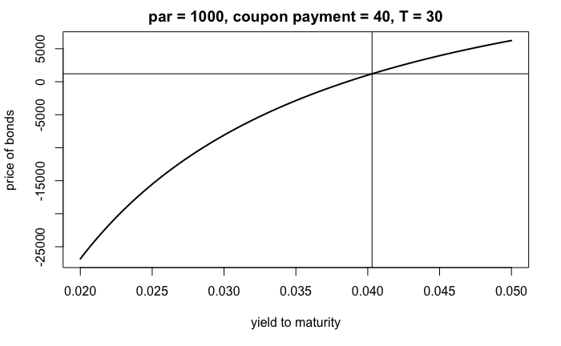

```r
abline(v=yield2M[2])
```

## Problem 3:

Use uniroot() to find the yield to maturity of the 30-year par $1,000 bond with coupon payments of $40 that is selling at $1,200.

```r
uniroot(function(r) (40/r + (1000 - 40/r)*(1+r)**(-60)) - 1200, c(0.02,0.05))
```

```
$root
[1] 0.03238059

$f.root
[1] 0.5345732

$iter
[1] 4

$init.it
[1] NA

$estim.prec
[1] 6.103516e-05
```

## Problem 4:

Find the yield to maturity of a par $10,000 bond selling at $9,800 with semiannual coupon payments equal to $280 and maturing in 8 years.

```r
uniroot(function(r) (280/r + (10000 - 280/r)*(1+r)**(-2*8)) - 9800, c(0.01,0.06))
```

```
$root
[1] 0.02958283

$f.root
[1] 0.5431041

$iter
[1] 4

$init.it
[1] NA

$estim.prec
[1] 6.103516e-05
```

## Problem 5:

Use uniroot() to find the yield to maturity of the 20-year par $1,000 bond with semiannual coupon payments of $35 that is selling at $1,050.

```r
uniroot(function(r) (35/r + (1000 - 35/r)*(1+r)**(-2*20)) - 1050, c(0.01,0.06))
```

```
$root
[1] 0.03273984

$f.root
[1] 0.004475269

$iter
[1] 5

$init.it
[1] NA

$estim.prec
[1] 0.0001010124
```

## Problem 6:

The yield to maturity is 0.035 on a par $1,000 bond selling at $950.10 and maturing in 5 years. What is the coupon payment?

```r
Coupon = uniroot(function(C) (C/0.035 + (1000 - C/0.035)*(1+0.035)**(-2*5)) - 950.1, c(0, 100))
cat("the coupon payment:",Coupon$root,"$")
```

```
the coupon payment: 28.99996 $
```

# Graphng Yield Curves:

The data set `mk.zero2` has yield curves of U.S. zero coupon bonds recorded monthly at 55 maturities. These maturities are in the data set `mk.maturity`.

```r
mk.maturity = read.csv("datasets/mk.maturity.csv", header=T)
mk.zero2 = read.csv("datasets/mk.zero2.csv", header=T)
plot(mk.maturity[,1], mk.zero2[5,2:56], type='l', xlab="maturity", ylab="yield")
#lines(mk.maturity[,1], mk.zero2[6,2:56], type='l', lty=2)
#lines(mk.maturity[,1], mk.zero2[7,2:56], type='l', lty=2)
lines(mk.maturity[,1], mk.zero2[8,2:56], type='l', lty=2)
```

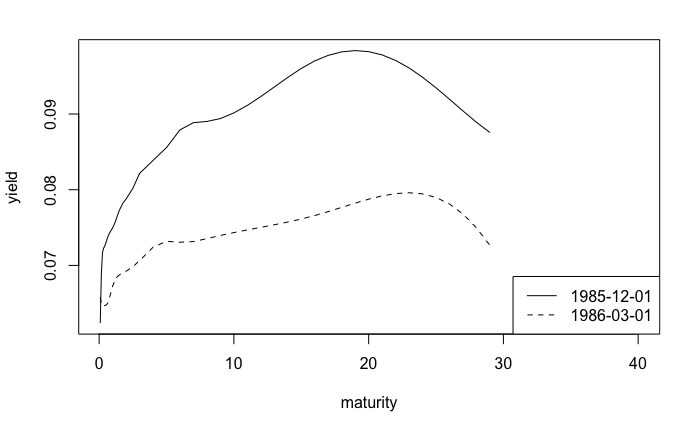

```r
legend("bottomright", c("1985-12-01", "1986-03-01"), lty = 1:4)
```

## Problem 7:

the yield curve 1-12-1985 and 1-3-1986 are increase to 18e year and 23e year. the curves of 1-12 is above curves of 3-1

## Problem 8:

```r
plot(mk.maturity[,1], mk.zero2[17,2:56], type="l", xlab = "maturity", ylab="Yield", main="1-12-1986 vs 1-3-1987", xlim=c(0,20))
lines(mk.maturity[,1], mk.zero2[20,2:56], type="l", lty=3)
```

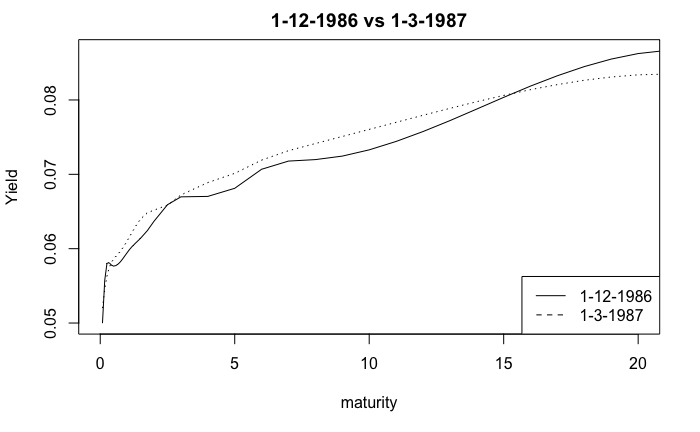

```r
legend("bottomright", c("1-12-1986","1-3-1987"), lty=1:2)
```

Two curves above are cut each other in many point

## Estimates forward rate for one month:

The next set of code estimates the forward rate for 1month. Line 1 estimates the integrated forward rate, called intForward, which is $Ty_t=\int_0^Tr(t)dt$ where r(t) is the forward rate. Line 3 interpolates the estimated 0 integrated forward rate onto a grid of 200 points from 0 to 20. This grid is created on line 2. If a function f is evaluated on a grid, $t_1,...,t_L$, then ${f(t_l)−f(t_{l−1})}/(t_l− t_{l−1})$ approximates $f′(\frac{t_l +t_{l−1}}{2})$ for l = 2,…,L. Line 4 numerically differentiates the integrated forward rate to approximate the forward rate on the grid calculated at Line 5.

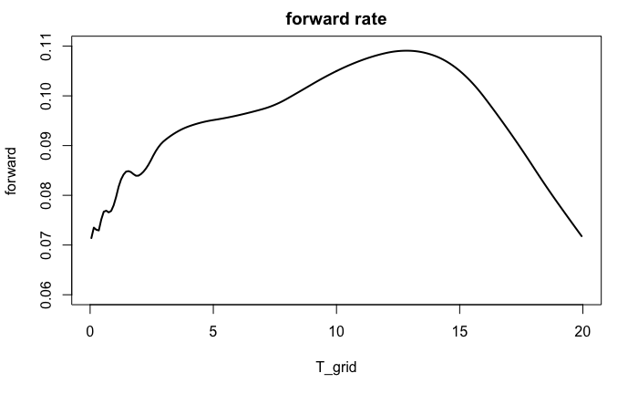

```r
intForward = mk.maturity[, 1] * mk.zero2[6, 2:56]
xout = seq(0, 20, length = 200)
z1 = spline(mk.maturity[ ,1], intForward, xout = xout)
forward = diff(z1$y) / diff(z1$x)
T_grid = (xout[-1] + xout[-200]) / 2
plot(T_grid, forward, type = "l", lwd = 2, ylim = c(0.06, 0.11), main="forward rate")
```

```r
intForward1 = mk.maturity[, 1] * mk.zero2[5, 2:56]
intForward2 = mk.maturity[, 1] * mk.zero2[6, 2:56]
intForward3 = mk.maturity[, 1] * mk.zero2[7, 2:56]
intForward4 = mk.maturity[, 1] * mk.zero2[8, 2:56]
xout = seq(0, 20, length = 200)
z1 = spline(mk.maturity[ ,1], intForward1, xout = xout)
z2 = spline(mk.maturity[ ,1], intForward2, xout = xout)
z3 = spline(mk.maturity[ ,1], intForward3, xout = xout)
z4 = spline(mk.maturity[ ,1], intForward4, xout = xout)
forward1 = diff(z1$y) / diff(z1$x)
forward2 = diff(z2$y) / diff(z2$x)
forward3 = diff(z3$y) / diff(z3$x)
forward4 = diff(z4$y) / diff(z4$x)
T_grid = (xout[-1] + xout[-200]) / 2
plot(T_grid, forward1, type = "l", lwd = 2, ylim = c(0.06, 0.12), main="forward rate", lty=1)
lines(T_grid, forward2, type = "l", lwd = 2, lty=2)
```

```r
lines(T_grid, forward3, type = "l", lwd = 2, lty=3)
lines(T_grid, forward4, type = "l", lwd = 2, lty=4)
```

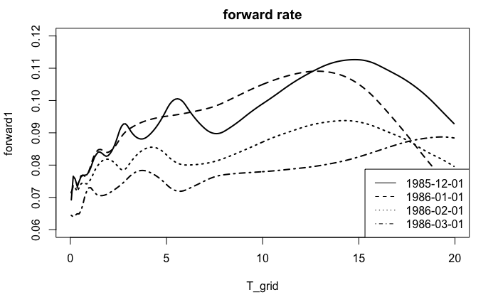

```r
legend("bottomright", c("1985-12-01", "1986-01-01",
      "1986-02-01", "1986-03-01"), lty = 1:4)
```